# The Impact of Education on Obesity

2025-03-20

[output not shown]

[output not shown]

### Selecting Variables and Merging Datasets

Load and examine the examination data form the NHANES 2017 to 2018 dataset

```r
BMI_2018 <- read_xpt("BMX_2018.xpt")
head(BMI_2018, 10)
```

| SEQN | BMDSTATS | BMXWT | BMIWT | BMXRECUM | BMIRECUM | BMXHEAD | BMIHEAD | BMXHT | BMIHT | BMXBMI | BMXLEG | BMILEG | BMXARML | BMIARML | BMXARMC | BMIARMC | BMXWAIST | BMIWAIST | BMXHIP | BMIHIP |
| --- | --- | --- | --- | --- | --- | --- | --- | --- | --- | --- | --- | --- | --- | --- | --- | --- | --- | --- | --- | --- |
| 93703 | 1 | 13.7 | 3 | 89.6 | NA | NA | NA | 88.6 | NA | 17.5 | NA | NA | 18.0 | NA | 16.2 | NA | 48.2 | NA | NA | NA |
| 93704 | 1 | 13.9 | NA | 95.0 | NA | NA | NA | 94.2 | NA | 15.7 | NA | NA | 18.6 | NA | 15.2 | NA | 50.0 | NA | NA | NA |
| 93705 | 1 | 79.5 | NA | NA | NA | NA | NA | 158.3 | NA | 31.7 | 37.0 | NA | 36.0 | NA | 32.0 | NA | 101.8 | NA | 110.0 | NA |
| 93706 | 1 | 66.3 | NA | NA | NA | NA | NA | 175.7 | NA | 21.5 | 46.6 | NA | 38.8 | NA | 27.0 | NA | 79.3 | NA | 94.4 | NA |
| 93707 | 1 | 45.4 | NA | NA | NA | NA | NA | 158.4 | NA | 18.1 | 38.1 | NA | 33.8 | NA | 21.5 | NA | 64.1 | NA | 83.0 | NA |
| 93708 | 1 | 53.5 | NA | NA | NA | NA | NA | 150.2 | NA | 23.7 | 31.8 | NA | 30.6 | NA | 27.4 | NA | 88.2 | NA | 90.1 | NA |
| 93709 | 1 | 88.8 | NA | NA | NA | NA | NA | 151.1 | NA | 38.9 | 31.9 | NA | 36.0 | NA | 38.1 | NA | 113.0 | NA | 131.3 | NA |
| 93710 | 1 | 10.2 | NA | 74.3 | NA | NA | NA | NA | NA | NA | NA | NA | 15.0 | NA | 16.0 | NA | NA | NA | NA | NA |
| 93711 | 1 | 62.1 | NA | NA | NA | NA | NA | 170.6 | NA | 21.3 | 40.1 | NA | 37.2 | NA | 30.8 | NA | 86.6 | NA | 90.7 | NA |
| 93712 | 1 | 58.9 | NA | NA | NA | NA | NA | 172.8 | NA | 19.7 | 44.5 | NA | 37.2 | NA | 28.7 | NA | 72.0 | NA | 88.2 | NA |

### Data Wrangling

Extract variables needed

```r
BMI_DOI_2018 <- BMI_2018[, c("SEQN", "BMXBMI")]
BMI_DOI_2018 <- BMI_DOI_2018 %>%
  rename(
    ID = SEQN,
    BMI = BMXBMI
  )
head(BMI_DOI_2018,1)
```

| ID | BMI |
| --- | --- |
| 93703 | 17.5 |

Load and examine data from the NHANES demographic dataset from the 2017-2018 survey

```r
DEM_2018 <- read_xpt("DEMO_2018.xpt")
head(DEM_2018,1)
```

| SEQN | SDDSRVYR | RIDSTATR | RIAGENDR | RIDAGEYR | RIDAGEMN | RIDRETH1 | RIDRETH3 | RIDEXMON | RIDEXAGM | DMQMILIZ | DMQADFC | DMDBORN4 | DMDCITZN | DMDYRSUS | DMDEDUC3 | DMDEDUC2 | DMDMARTL | RIDEXPRG | SIALANG | SIAPROXY | SIAINTRP | FIALANG | FIAPROXY | FIAINTRP | MIALANG | MIAPROXY | MIAINTRP | AIALANGA | DMDHHSIZ | … |
| --- | --- | --- | --- | --- | --- | --- | --- | --- | --- | --- | --- | --- | --- | --- | --- | --- | --- | --- | --- | --- | --- | --- | --- | --- | --- | --- | --- | --- | --- | --- |
| 93703 | 10 | 2 | 2 | 2 | NA | 5 | 6 | 2 | 27 | NA | NA | 1 | 1 | NA | NA | NA | NA | NA | 1 | 1 | 2 | 1 | 2 | 2 | NA | NA | NA | NA | 5 | … |

Extract needed variables

```r
DEM_DOI_2018 <- DEM_2018 %>%
  select("SEQN", "RIAGENDR", "RIDAGEYR", "RIDRETH1", "DMDEDUC2", "INDHHIN2") %>%
  rename(
    ID = SEQN,              # Respondent sequence number
    Gender = RIAGENDR,      # Gender
    Age_Years = RIDAGEYR,   # Age in years
    Race = RIDRETH1,        # Race/Ethnicity
    Education = DMDEDUC2,   # Education level for 20+ adults
    Household_Income = INDHHIN2  # Annual household income
  )

head(DEM_DOI_2018, 1)
```

| ID | Gender | Age_Years | Race | Education | Household_Income |
| --- | --- | --- | --- | --- | --- |
| 93703 | 2 | 2 | 5 | NA | 15 |

Merge the data from the examination and demographic datasets

```r
# before merging, sort datasets by SEQN (unique respondent ID)
BMI_DOI_2018 <- BMI_DOI_2018 %>% arrange(ID)
DEM_DOI_2018 <- DEM_DOI_2018 %>% arrange(ID)
#check sorted datasets
head(BMI_DOI_2018,5)
```

| ID | BMI |
| --- | --- |
| 93703 | 17.5 |
| 93704 | 15.7 |
| 93705 | 31.7 |
| 93706 | 21.5 |
| 93707 | 18.1 |

```r
head(DEM_DOI_2018,5)
```

| ID | Gender | Age_Years | Race | Education | Household_Income |
| --- | --- | --- | --- | --- | --- |
| 93703 | 2 | 2 | 5 | NA | 15 |
| 93704 | 1 | 2 | 3 | NA | 15 |
| 93705 | 2 | 66 | 4 | 2 | 3 |
| 93706 | 1 | 18 | 5 | NA | NA |
| 93707 | 1 | 13 | 5 | NA | 10 |

```r
data <- merge(BMI_DOI_2018, DEM_DOI_2018, by = "ID")
head(data, 10)
```

|  | ID | BMI | Gender | Age_Years | Race | Education | Household_Income |
| --- | --- | --- | --- | --- | --- | --- | --- |
| 1 | 93703 | 17.5 | 2 | 2 | 5 | NA | 15 |
| 2 | 93704 | 15.7 | 1 | 2 | 3 | NA | 15 |
| 3 | 93705 | 31.7 | 2 | 66 | 4 | 2 | 3 |
| 4 | 93706 | 21.5 | 1 | 18 | 5 | NA | NA |
| 5 | 93707 | 18.1 | 1 | 13 | 5 | NA | 10 |
| 6 | 93708 | 23.7 | 2 | 66 | 5 | 1 | 6 |
| 7 | 93709 | 38.9 | 2 | 75 | 4 | 4 | 2 |
| 8 | 93710 | NA | 2 | 0 | 3 | NA | 15 |
| 9 | 93711 | 21.3 | 1 | 56 | 5 | 5 | 15 |
| 10 | 93712 | 19.7 | 1 | 18 | 1 | NA | 4 |

```r
#and export/save it as csv
write.csv(data, "BMI And Demographic data for the US 2017 to 2018.csv")
```

### Data Cleaning and Recoding

```r
# our primary research question is:
# what is the relationship between obesity and education level among the US adults?
# so let's investigate the BMI variable:
summary(data)
```

```
##        ID              BMI            Gender        Age_Years
##  Min.   : 93703   Min.   :12.30   Min.   :1.000   Min.   : 0.00
##  1st Qu.: 96001   1st Qu.:20.40   1st Qu.:1.000   1st Qu.:11.00
##  Median : 98309   Median :25.80   Median :2.000   Median :31.00
##  Mean   : 98315   Mean   :26.58   Mean   :1.509   Mean   :34.44
##  3rd Qu.:100625   3rd Qu.:31.30   3rd Qu.:2.000   3rd Qu.:58.00
##  Max.   :102956   Max.   :86.20   Max.   :2.000   Max.   :80.00
##                   NA's   :699
##       Race         Education     Household_Income
##  Min.   :1.000   Min.   :1.000   Min.   : 1.00
##  1st Qu.:3.000   1st Qu.:3.000   1st Qu.: 6.00
##  Median :3.000   Median :4.000   Median : 8.00
##  Mean   :3.233   Mean   :3.527   Mean   :12.43
##  3rd Qu.:4.000   3rd Qu.:4.000   3rd Qu.:14.00
##  Max.   :5.000   Max.   :9.000   Max.   :99.00
##                  NA's   :3439    NA's   :384
```

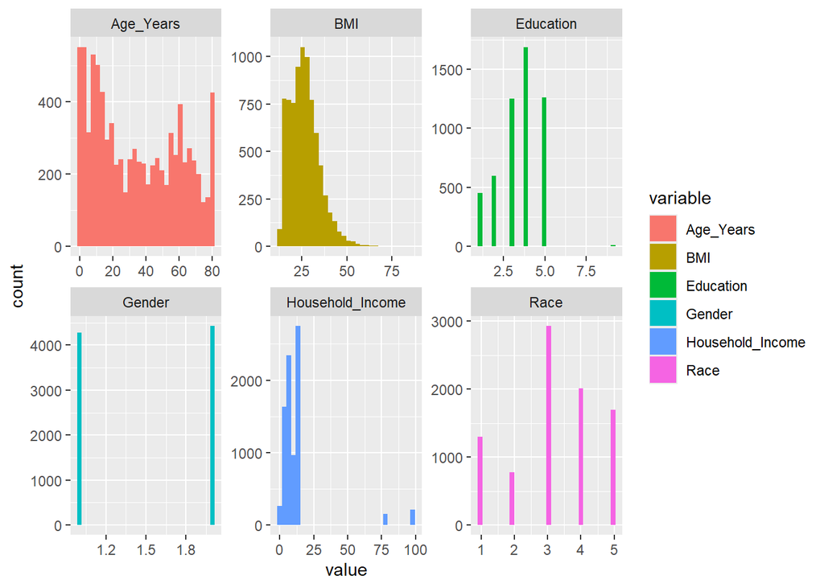

```r
# Convert data to long format
data_long <- data %>%
  pivot_longer(cols = c(Gender, Household_Income, Race, Education, Age_Years, BMI),
               names_to = "variable",
               values_to = "value")
ggplot(data_long, aes(x=value, fill=variable)) +
 geom_histogram() +
 facet_wrap(~variable, nrow=2, scale='free')
```

There are some outliers in education, household income, and BMI.

```r
summary(data$BMI)
```

```
##    Min. 1st Qu.  Median    Mean 3rd Qu.    Max.    NA's
##   12.30   20.40   25.80   26.58   31.30   86.20     699
```

```r
# filter out the respondents with missing BMI values
filtered_data <- data %>%
  filter(!is.na(BMI))
summary(filtered_data$BMI)
```

```
##    Min. 1st Qu.  Median    Mean 3rd Qu.    Max.
##   12.30   20.40   25.80   26.58   31.30   86.20
```

```r
# we are interested in adults so we will filter out respondents younger than 20
filtered_data <- filtered_data %>%
  filter(filtered_data$Age_Years >= 20)
summary(filtered_data$Age_Years)
```

```
##    Min. 1st Qu.  Median    Mean 3rd Qu.    Max.
##   20.00   36.00   53.00   51.24   65.00   80.00
```

```r
#only choose variables we need
filtered_data = filtered_data %>%
  select(BMI, Gender, Age_Years, Race, Education, Household_Income)
```

```r
table(filtered_data$Household_Income)
```

```
##
##   1   2   3   4   5   6   7   8   9  10  12  13  14  15  77  99
## 130 141 235 303 307 525 517 345 314 243 199  66 453 908 103 128
```

```r
filtered_data <- filtered_data %>%
  #77 refuse, 99 dont know, and NA are missing
  filter(!Household_Income %in% c(77, 99, NA))  # Remove unwanted values
table(filtered_data$Household_Income)
```

```
##
##   1   2   3   4   5   6   7   8   9  10  12  13  14  15
## 130 141 235 303 307 525 517 345 314 243 199  66 453 908
```

```r
# 7 and 9 are "Dont know" and "refused" while NA is missing
table(filtered_data$Education)
```

```
##
##    1    2    3    4    5    7    9
##  352  512 1138 1533 1146    1    4
```

```r
filtered_data <- filtered_data %>%
  filter(Education %in% 1:5) #only choose categories 1 to 5: from 9th grade to college graduate
table(filtered_data$Education)
```

```
##
##    1    2    3    4    5
##  352  512 1138 1533 1146
```

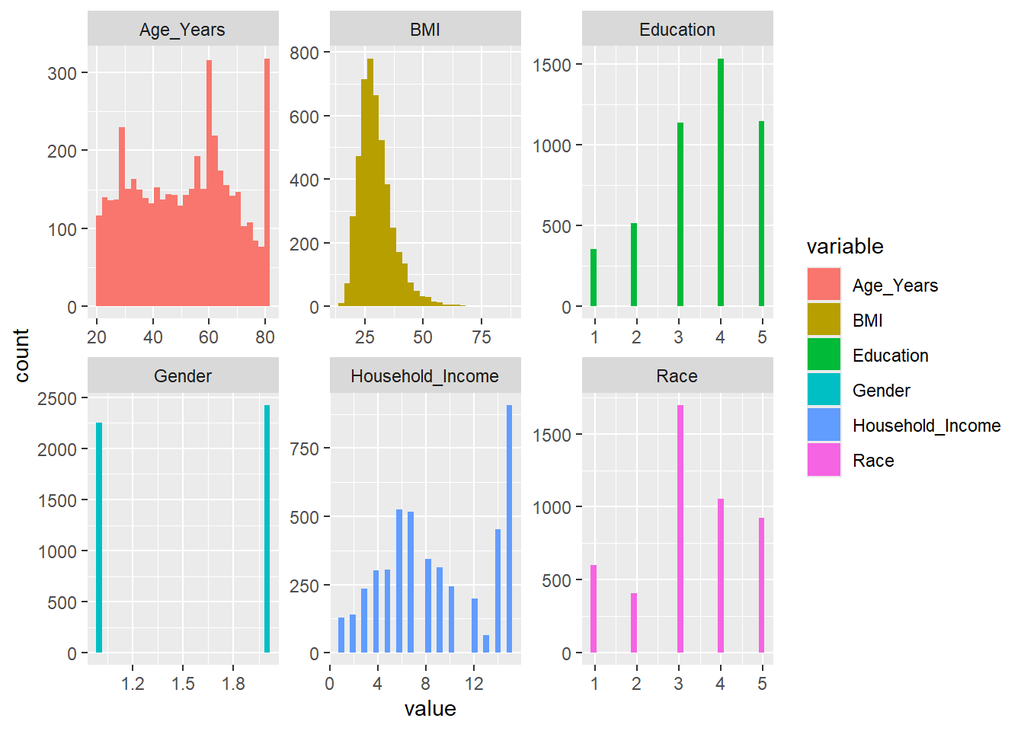

```r
# Convert data to long format
filtered_data_long <- filtered_data %>%
  pivot_longer(cols = c(Gender, Household_Income, Race, Education, Age_Years, BMI),
               names_to = "variable",
               values_to = "value")
ggplot(filtered_data_long, aes(x=value, fill=variable)) +
 geom_histogram() +
 facet_wrap(~variable, nrow=2, scale='free')
```

### Recoding Variables

```r
# Interested in the presence or absence of obesity
# A BMI >= 30 is classified as obese (1), while <30 is not obese (0):
recoded <- filtered_data %>%
  mutate(obesity = ifelse(BMI >= 30, 1, 0),
         #Education level is a categorical variable whereby:
         #1 = Less than 9th grade
         #2 = 9-11th grade (Includes 12th grade with no diploma)
         #3 = High school graduate/GED or equivalent
         #4 = Some college or AA degree
         #5 = College graduate or above
         #recode according to college graduated or not
        College_graduate = case_when(
           Education == 1 ~ 0,
           Education == 2 ~ 0,
           Education == 3 ~ 0,
           Education == 4 ~ 0,
           Education == 5 ~ 1),
         # Recode gender, by introducing a female variable where 1=female, male = 0
         Female = case_when(
           Gender == 1 ~ 0,
           Gender == 2 ~ 1),
         # group hispanics, whites, black and other races
         Race = case_when(
           Race == 1 ~ 1, #Mexican American
           Race == 2 ~ 1, # Other Hispanic
           Race == 3 ~ 2, # non-hispanic Whites
           Race == 4 ~ 3, #black
           Race == 5 ~ 4),#others
         # Recode income with actual estimates
         Income = case_when(
           Household_Income == 1  ~ 2500,
           Household_Income == 2  ~ 7500,
           Household_Income == 3  ~ 12500,
           Household_Income == 4  ~ 17500,
           Household_Income == 5  ~ 22500,
           Household_Income == 6  ~ 30000,
           Household_Income == 7  ~ 40000,
           Household_Income == 8  ~ 50000,
           Household_Income == 9  ~ 60000,
           Household_Income == 10 ~ 70000,
           Household_Income == 12 ~ 17500,
           Household_Income == 13 ~ 22500,
           Household_Income == 14 ~ 85000,
           Household_Income == 15 ~ 100000)
         ) %>%
  mutate(across(c(obesity, Female, Race, College_graduate),
                as.factor))%>%
  select(obesity, Female, Age_Years,
         Income, Race,College_graduate)
head(recoded,5)
```

|  | obesity | Female | Age_Years | Income | Race | College_graduate |
| --- | --- | --- | --- | --- | --- | --- |
| 1 | 1 | 1 | 66 | 12500 | 3 | 0 |
| 2 | 0 | 1 | 66 | 30000 | 4 | 0 |
| 3 | 1 | 1 | 75 | 7500 | 3 | 0 |
| 4 | 0 | 0 | 56 | 100000 | 4 | 1 |
| 5 | 0 | 0 | 67 | 30000 | 2 | 0 |

```r
# Convert data to long format
recoded_long <- recoded %>%
  pivot_longer(cols = c(Age_Years,Income),
               names_to = "variable",
               values_to = "value")

recoded_summary_continuous_variables <- recoded_long %>%
  group_by(variable) %>%
  summarize(
    mean_value = mean(value),
    stddev_value = sd(value),
    min_value = min(value),
    max_value = max(value),
    count = n()
  )

# View summary
print(recoded_summary_continuous_variables)
```

```
## # A tibble: 2 × 6
##   variable  mean_value stddev_value min_value max_value count
##   <chr>          <dbl>        <dbl>     <dbl>     <dbl> <int>
## 1 Age_Years       51.2         17.6        20        80  4681
## 2 Income       51319.       32337.       2500    100000  4681
```

```r
# Visualize summary
```

```r
# Create a summary of categorical variables
categorical_summary <- recoded %>%
  select(obesity, Race, Female, College_graduate) %>%
  pivot_longer(cols = everything(), names_to = "variable", values_to = "category") %>%
  group_by(variable, category) %>%
  summarise(count = n(), proportion = n() / nrow(recoded)) %>%
  ungroup()
# Print in a clear table format
print(categorical_summary)
```

```
## # A tibble: 10 × 4
##    variable         category count proportion
##    <chr>            <fct>    <int>      <dbl>
##  1 College_graduate 0         3535      0.755
##  2 College_graduate 1         1146      0.245
##  3 Female           0         2255      0.482
##  4 Female           1         2426      0.518
##  5 Race             1         1005      0.215
##  6 Race             2         1697      0.363
##  7 Race             3         1056      0.226
##  8 Race             4          923      0.197
##  9 obesity          0         2722      0.581
## 10 obesity          1         1959      0.419
```

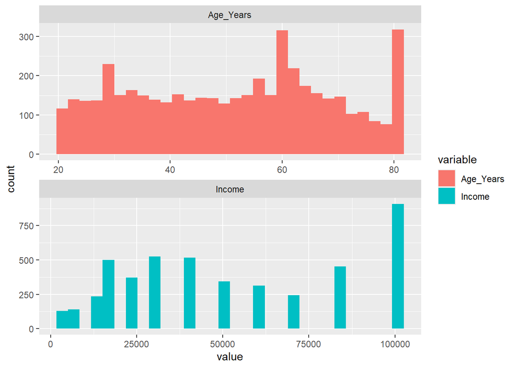

```r
# Convert data to long format
cont_data_long <- recoded %>%
  pivot_longer(cols = c(Income, Age_Years),
               names_to = "variable",
               values_to = "value")
ggplot(cont_data_long, aes(x=value, fill=variable)) +
 geom_histogram() +
 facet_wrap(~variable, nrow=2, scale='free')
```

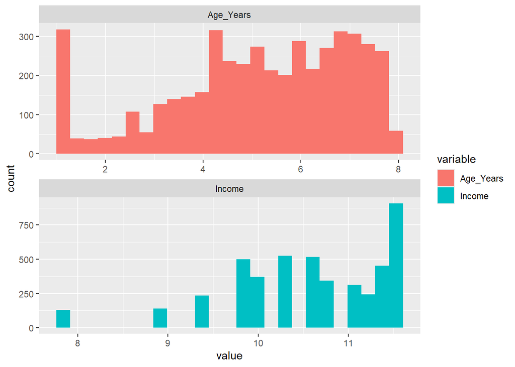

```r
recoded <- recoded %>%
  mutate(
    # Define K as the max value + 1
    # Apply the transformation
    Age_Years<- sqrt((max(Age_Years) + 1) - Age_Years),
    Income = log(Income ) # Log transform income due to skewness
  )
recoded$Age_Years <- recoded$`Age_Years <- sqrt((max(Age_Years) + 1) - Age_Years)`
# Convert data to long format
cont_data_long <- recoded %>%
  pivot_longer(cols = c(Income, Age_Years),
               names_to = "variable",
               values_to = "value")
ggplot(cont_data_long, aes(x=value, fill=variable)) +
 geom_histogram(bins = 25) +
 facet_wrap(~variable, nrow=2, scale='free')
```

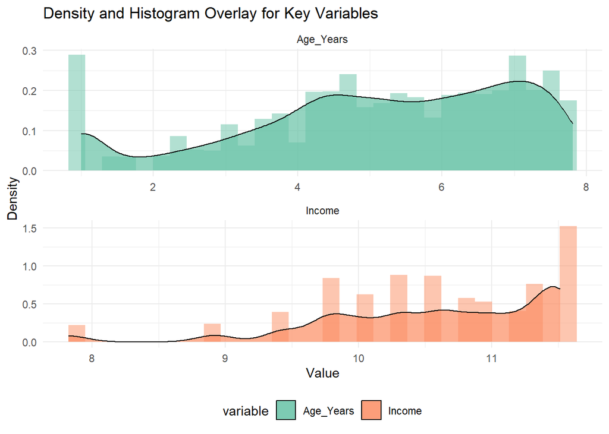

```r
ggplot(cont_data_long, aes(x = value, fill = variable)) +
  geom_histogram(aes(y = ..density..), alpha = 0.5, position = "identity", bins = 30) +
  geom_density(alpha = 0.7, color = "black") +
  facet_wrap(~variable, nrow = 3, scales = 'free') +
  scale_fill_brewer(palette = "Set2") +
  scale_x_continuous(labels = scales::comma) +
  theme_minimal() +
  theme(legend.position = "bottom") +
  labs(title = "Density and Histogram Overlay for Key Variables",
       x = "Value",
       y = "Density")
```

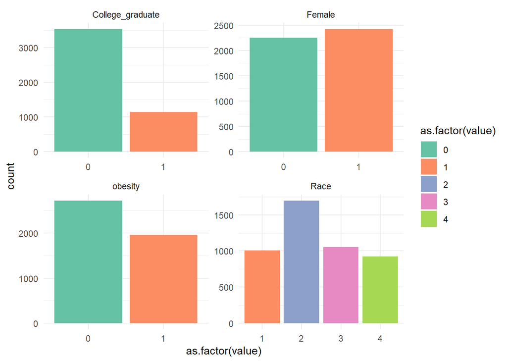

```r
# Convert data to long format
cat_recoded_long <- recoded%>%
  pivot_longer(cols = c(Female, obesity, Race, College_graduate),
               names_to = "variable",
               values_to = "value")

ggplot(cat_recoded_long, aes(x=as.factor(value), fill=as.factor(value))) +
  geom_bar() +
  facet_wrap(~variable, nrow=3, scales='free') +
  scale_fill_brewer(palette = "Set2") +
  theme_minimal()
```

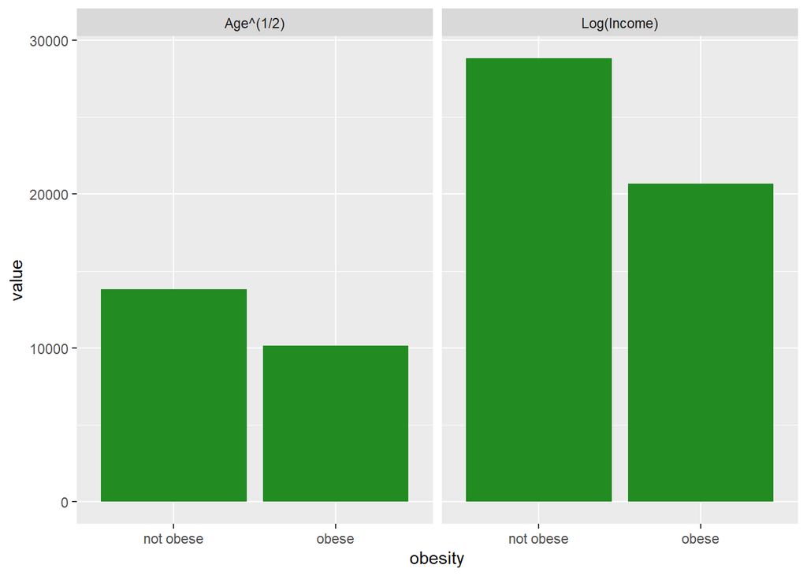

```r
# visualize variables grouped by gender, race, obesity, and income
### Recoding Variables with textual labels for visual comparison
labelled <-recoded %>%
  mutate(obesity = ifelse(obesity == 1, "obese", "not obese"),
         Gender = case_when(
           Female == 0 ~ "male",
           Female == 1 ~ "female"),
         Race = case_when(
           Race == 1 ~ "Hispanic", # non-hispanic Whites
           Race == 2 ~ "white",
           Race == 3 ~ "Black",
           Race == 4 ~ "Other"),
         College_graduate = case_when(
           College_graduate == 1 ~ "college graduate",
           College_graduate == 0 ~ "Not college graduate"
         )
         ) %>%
  select(obesity, Gender, Race, Age_Years, College_graduate, Income)

variable_names <- list(
  "Age_Years" = "Age^(1/2)",
  "Income" = "Log(Income)"
)


variable_labeller <- function(variable,value){
  return(variable_names[value])
}

labelled_long <- gather(labelled, key="measure", value="value",
                       c("Income", "Age_Years"))

ggplot(labelled_long, aes(x=obesity, y=value))+
  geom_bar(stat='identity', fill="forest green")+
  facet_wrap(~measure, labeller=variable_labeller)
```

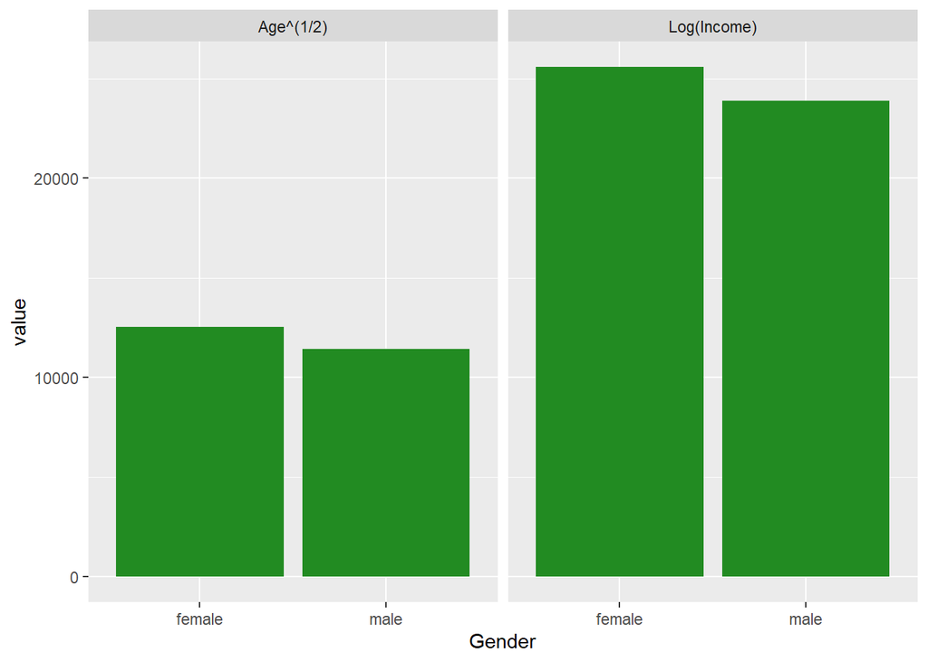

```r
ggplot(labelled_long, aes(x=Gender, y=value))+
  geom_bar(stat='identity', fill="forest green")+
  facet_wrap(~measure, labeller=variable_labeller)
```

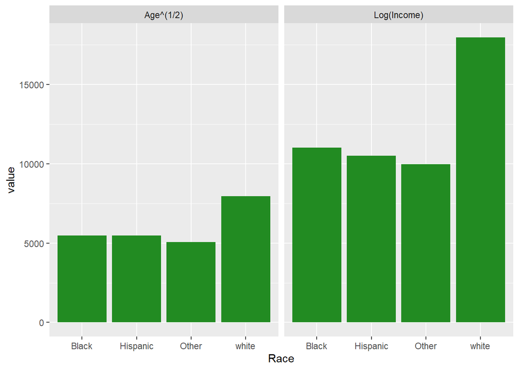

```r
ggplot(labelled_long, aes(x=Race, y=value))+
  geom_bar(stat='identity', fill="forest green")+
  facet_wrap(~measure, labeller=variable_labeller)
```

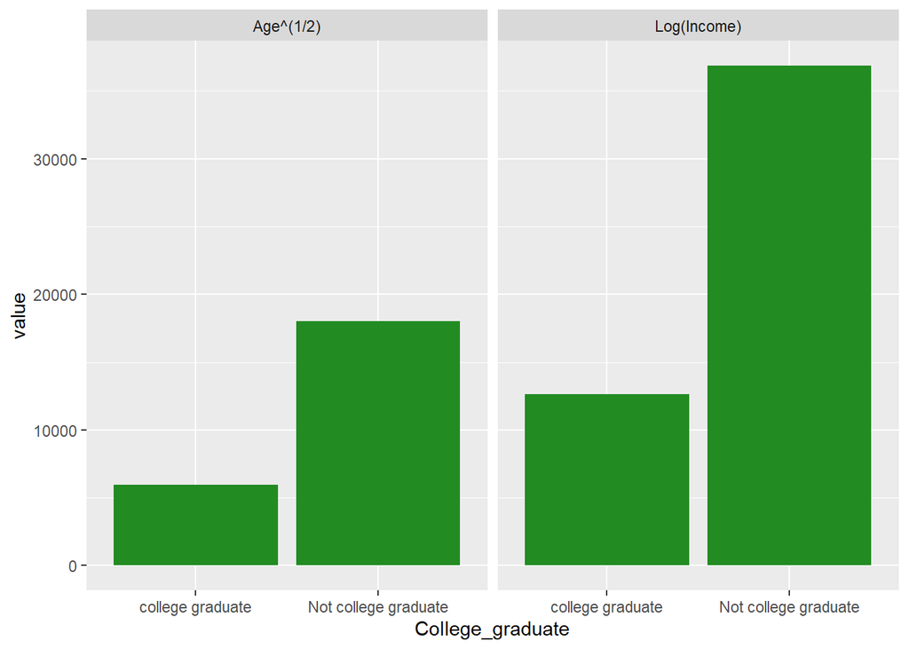

```r
ggplot(labelled_long, aes(x=College_graduate, y=value))+
  geom_bar(stat='identity', fill="forest green")+
  facet_wrap(~measure, labeller=variable_labeller)
```

### Modeling The Relationship Between Obesity and Education

#### Logistic Regression

Since the dependent variable (obesity) is binary (0 = Not Obese, 1 = Obese), logistic regression is best suited for this statistical modelling.

$$\log \left(\frac{P(Obesity_i)}{1 - P(Obesity_i)}\right) = \beta_0 + \beta_1 (CollegeGraduate_i) + \varepsilon_i$$

Where:

$\ P(Obesity_i)$ is the probability of being obese. The left-hand side represents the **log-odds** of obesity. $\ (\beta_0)$ is the intercept. $\ (\beta_1)$ represents the effect of college education on obesity. $\ (\varepsilon_i)$ is the error term.

Since logistic regression works with log-odds, there is need to convert the coefficient into an odds ratio using:

$$\text{Odds Ratio} = e^{\beta_1}$$

Moreover, the coefficient intervals also need to be computed for the odds ratio:
$$CI = \left(e^{Lower \ CI}, e^{Upper \ CI}\right)$$

```r
# Logistic regression (base model) for obesity and education
logit_edu_model <- glm(obesity ~ College_graduate, data = recoded, family = binomial())
summary (logit_edu_model)
```

```
##
## Call:
## glm(formula = obesity ~ College_graduate, family = binomial(),
##     data = recoded)
##
## Coefficients:
##                   Estimate Std. Error z value Pr(>|z|)
## (Intercept)       -0.20267    0.03381  -5.994 2.05e-09 ***
## College_graduate1 -0.53798    0.07166  -7.508 6.01e-14 ***
## ---
## Signif. codes:  0 '***' 0.001 '**' 0.01 '*' 0.05 '.' 0.1 ' ' 1
##
## (Dispersion parameter for binomial family taken to be 1)
##
##     Null deviance: 6364.3  on 4680  degrees of freedom
## Residual deviance: 6306.1  on 4679  degrees of freedom
## AIC: 6310.1
##
## Number of Fisher Scoring iterations: 4
```

College graduates have a log odds -0.538, indicating that college graduates are less likely to be obese than non-graduates.This is statistically significant at p<0.0001. Intercept, -0.20267, represents the baseline log-odds of obesity for non-college graduates.

The change in deviance from 6364 in null deviance to 6306 in residual deviance highlights that college education indeed explains some variability in obesity occurence.

The Akaike Information Criterion (AIC) value is quite high, 6310, which suggests that adding more variables could help explain the variability in obesity presence.

```r
# Compute odds ratio
odds_ratio <- exp(coef(logit_edu_model))
# Compute confidence intervals for odds ratios
CI_ratio <- exp(confint(logit_edu_model))
odds_ratio
```

```
##       (Intercept) College_graduate1
##         0.8165468         0.5839275
```

```r
CI_ratio
```

```
##                       2.5 %    97.5 %
## (Intercept)       0.7641279 0.8724323
## College_graduate1 0.5070521 0.6715324
```

Following conversion to odds ratio, it is evident that college graduates have approximately 41.6% lower odds of being obese compared to non-graduates.

The confidence interval for odd ratios further show that 95% Confidence Interval for the odds ratio indicates a statistically significant negative relationship.

We can visualize this using several libraries:

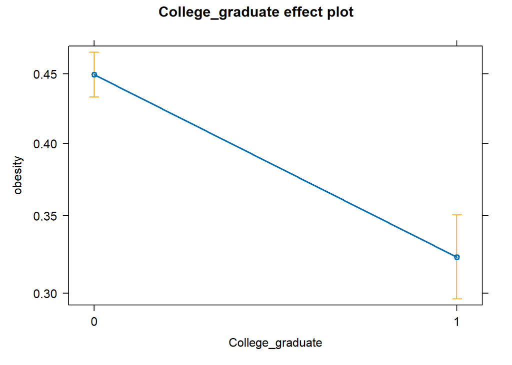

```r
#effects library
#visualize the effect of education on obesity
plot(effect("College_graduate", logit_edu_model))
```

OR:

```r
## visual theme
theme_set(theme_minimal())
okabeito <- c('#E69F00', '#56B4E9', '#009E73', '#F0E442', '#0072B2', '#D55E00', '#CC79A7', '#999999', '#000000')
options(ggplot2.discrete.fill = okabeito)
options(ggplot2.discrete.colour = okabeito)
options(width = 1000)
```

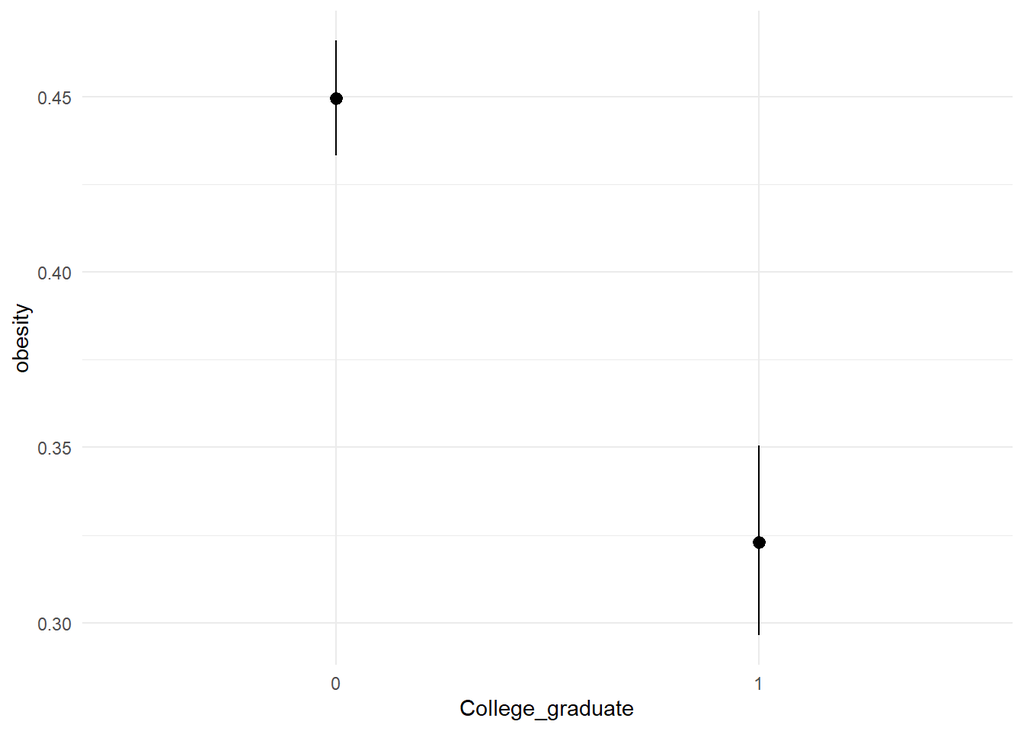

```r
plot_predictions(logit_edu_model, condition = c("College_graduate"))
```

OR: use marginal effects and ggplot:

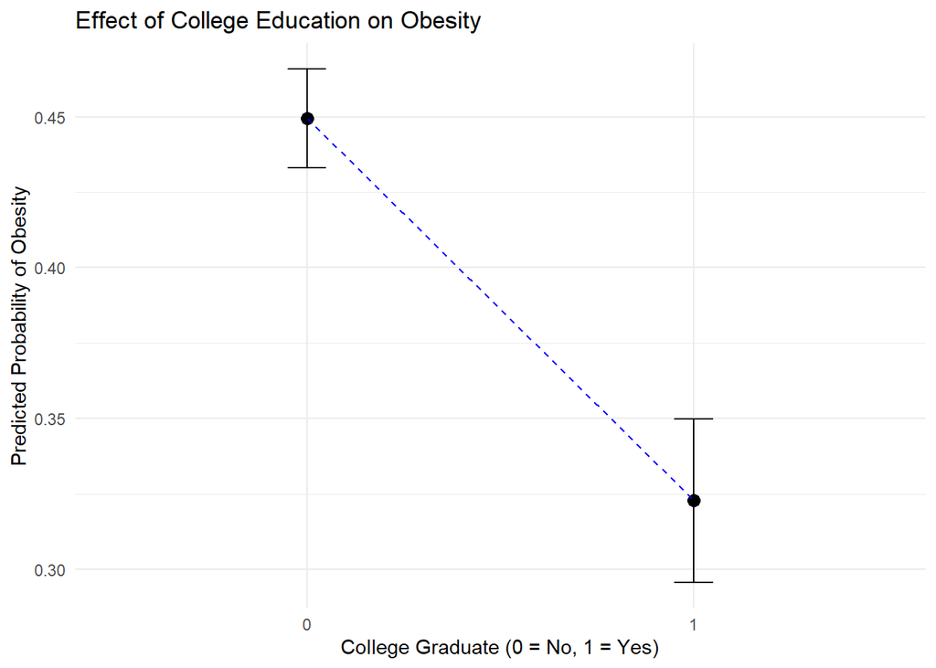

```r
# marginaleffects and ggplot2
# Get predicted values
preds <- predictions(logit_edu_model, by = "College_graduate")

# Create a connected line plot
ggplot(preds, aes(x = College_graduate, y = estimate)) +
  geom_point(size = 3) +
  geom_line(group = 1, linetype = "dashed", color = "blue") +  # Connect points
  geom_errorbar(aes(ymin = conf.low, ymax = conf.high), width = 0.1) +  # Error bars
  labs(title = "Effect of College Education on Obesity",
       x = "College Graduate (0 = No, 1 = Yes)",
       y = "Predicted Probability of Obesity") +
  theme_minimal()
```

##### Omitted Variable Bias

Similar to linear regression, if a key explanatory variable is left out, the estimated coefficients might be biased, leading to incorrect conclusions.

##### Likelihood Ratio Test

This tests if adding more variables significantly improves model fit. Thus, the upadate model formula is:

$$\log \left(\frac{P(Obesity_i)}{1 - P(Obesity_i)}\right) = \beta_0 + \beta_1 (CollegeGraduate_i) + \beta_2 (Income_i) + \beta_3 (Race_i) + \beta_4 (Age_i) + \beta_5 (Gender) + \varepsilon_i$$

```r
# Full model (adding more predictors)
logit_full_model <- glm(obesity ~ College_graduate + Income + Race + Age_Years + Female,
                        data = recoded, family = binomial())
summary(logit_full_model)
```

```
##
## Call:
## glm(formula = obesity ~ College_graduate + Income + Race + Age_Years +
##     Female, family = binomial(), data = recoded)
##
## Coefficients:
##                   Estimate Std. Error z value Pr(>|z|)
## (Intercept)       -1.25402    0.40323  -3.110  0.00187 **
## College_graduate1 -0.40047    0.07811  -5.127 2.94e-07 ***
## Income             0.07979    0.03769   2.117  0.03424 *
## Race2             -0.04220    0.08170  -0.516  0.60553
## Race3              0.18596    0.08901   2.089  0.03668 *
## Race4             -0.94755    0.10320  -9.182  < 2e-16 ***
## Age_Years          0.04325    0.01633   2.649  0.00806 **
## Female1            0.18008    0.06082   2.961  0.00307 **
## ---
## Signif. codes:  0 '***' 0.001 '**' 0.01 '*' 0.05 '.' 0.1 ' ' 1
##
## (Dispersion parameter for binomial family taken to be 1)
##
##     Null deviance: 6364.3  on 4680  degrees of freedom
## Residual deviance: 6143.2  on 4673  degrees of freedom
## AIC: 6159.2
##
## Number of Fisher Scoring iterations: 4
```

```r
#likelihood ratio test
anova(logit_edu_model, logit_full_model, test = "Chisq")
```

|  | Resid. Df | Resid. Dev | Df | Deviance | Pr(>Chi) |
| --- | --- | --- | --- | --- | --- |
| 1 | 4679 | 6306.122 | NA | NA | NA |
| 2 | 4673 | 6143.231 | 6 | 162.891 | 1.44558e-32 |

The likelihood ratio test suggests that Model 2 (which includes additional variables: Income, Race, Age, and Female) significantly improves the fit compared to Model 1 (which only has College Graduate as a predictor). Deviance Drop = 162.89, which is quite substantial. Difference = 6 df (which matches the number of additional predictors added):Income, Race2(White), Race3(Black), Race 4(others), Age, and Female. Most importantly: The significance test (Likelihood Ratio Test): p-value < 2.2e-16 (extremely significant) This means that adding Income, Race, Age, and Female significantly improves model fit.

```r
my.html3 <- htmlreg(
  list(logit_edu_model, logit_full_model),
  digits = 4,
  include.ci = FALSE
)

write(my.html3, "mylogisticmodels.html")

includeHTML("mylogisticmodels.html")
```

Statistical models

|  | Model 1 | Model 2 |
| --- | --- | --- |
| (Intercept) | -0.2027*** | -1.2540** |
|  | (0.0338) | (0.4032) |
| College_graduate1 | -0.5380*** | -0.4005*** |
|  | (0.0717) | (0.0781) |
| Income |  | 0.0798* |
|  |  | (0.0377) |
| Race2 |  | -0.0422 |
|  |  | (0.0817) |
| Race3 |  | 0.1860* |
|  |  | (0.0890) |
| Race4 |  | -0.9475*** |
|  |  | (0.1032) |
| Age_Years |  | 0.0433** |
|  |  | (0.0163) |
| Female1 |  | 0.1801** |
|  |  | (0.0608) |
| AIC | 6310.1220 | 6159.2311 |
| BIC | 6323.0246 | 6210.8412 |
| Log Likelihood | -3153.0610 | -3071.6155 |
| Deviance | 6306.1220 | 6143.2311 |
| Num. obs. | 4681 | 4681 |

***p < 0.001; **p < 0.01; *p < 0.05

After controlling for other factors, here is the visualized effect of each variables grouped by college education on obesity:

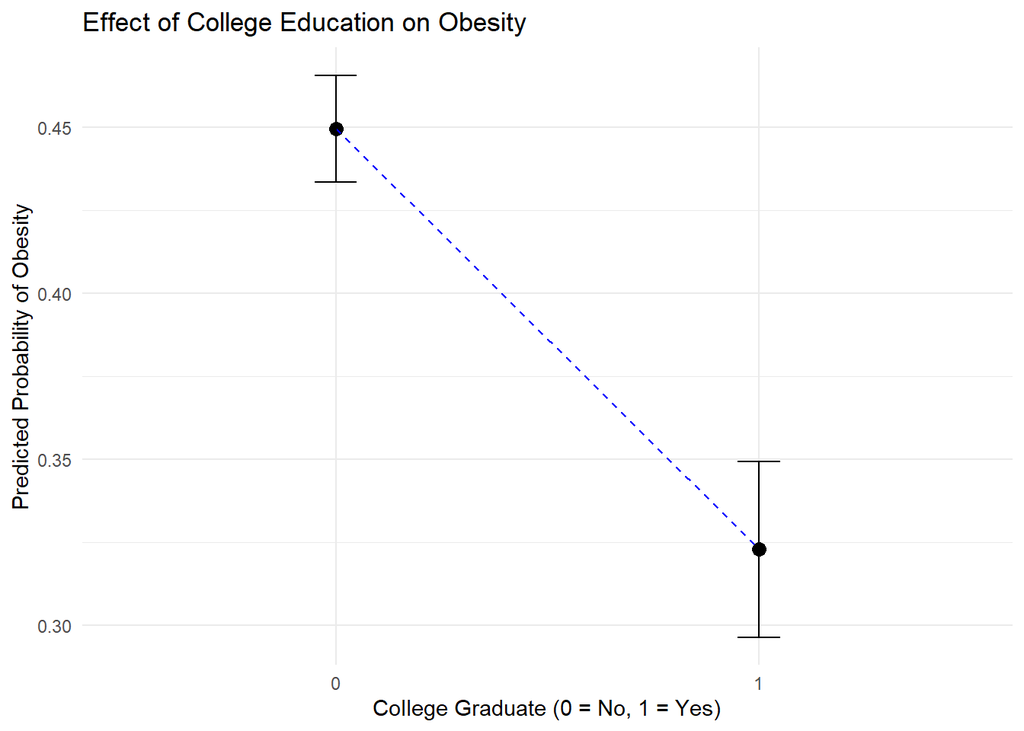

```r
# visualize effect of education on obesity
# Get predicted values
preds2 <- predictions(logit_full_model, by = c("College_graduate"
                                               )
)

# Create a connected line plot
ggplot(preds2, aes(x = College_graduate, y = estimate)) +
  geom_point(size = 3) +
  geom_line(group = 1, linetype = "dashed", color = "blue") +  # Connect points
  geom_errorbar(aes(ymin = conf.low, ymax = conf.high), width = 0.1) +  # Error bars
  labs(title = "Effect of College Education on Obesity",
       x = "College Graduate (0 = No, 1 = Yes)",
       y = "Predicted Probability of Obesity") +
  theme_minimal()
```

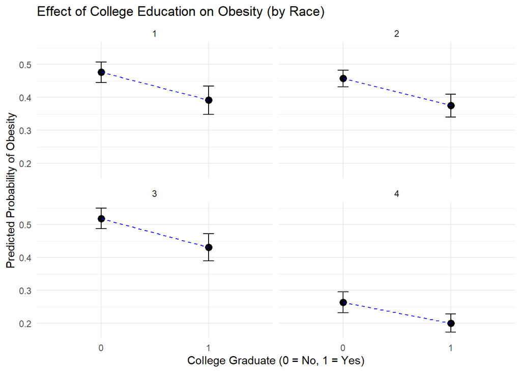

```r
# Effect of College Education on Obesity (by Race)
# Get predicted values
preds3 <- predictions(logit_full_model, by = c("College_graduate", "Race")
)

ggplot(preds3, aes(x = College_graduate, y = estimate, group = Race)) +
  geom_point(size = 3) +
  geom_line(linetype = "dashed", color = "blue") +
  geom_errorbar(aes(ymin = conf.low, ymax = conf.high), width = 0.1) +
  labs(title = "Effect of College Education on Obesity (by Race)",
       x = "College Graduate (0 = No, 1 = Yes)",
       y = "Predicted Probability of Obesity") +
  facet_wrap(~Race) +  # Creates separate plots for different racial groups
  theme_minimal()
```

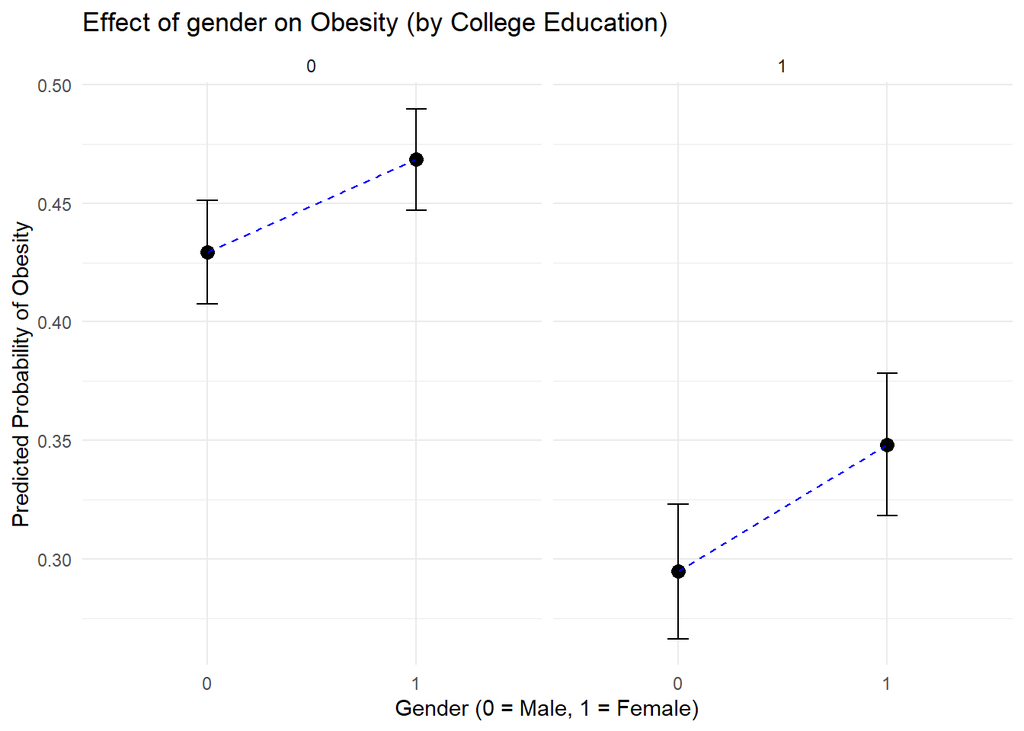

```r
#Effect of gender on Obesity (by education)
# Get predicted values
preds4 <- predictions(logit_full_model, by = c("Female", "College_graduate"
                                               )
)

ggplot(preds4, aes(x = Female, y = estimate, group=College_graduate)) +
  geom_point(size = 3) +
  geom_line(linetype = "dashed", color = "blue") +
  geom_errorbar(aes(ymin = conf.low, ymax = conf.high), width = 0.1) +
  labs(title = "Effect of gender on Obesity (by College Education)",
       x = "Gender (0 = Male, 1 = Female)",
       y = "Predicted Probability of Obesity") +
  facet_wrap(~College_graduate) +  # Creates separate plots for each college group
  theme_minimal()
```

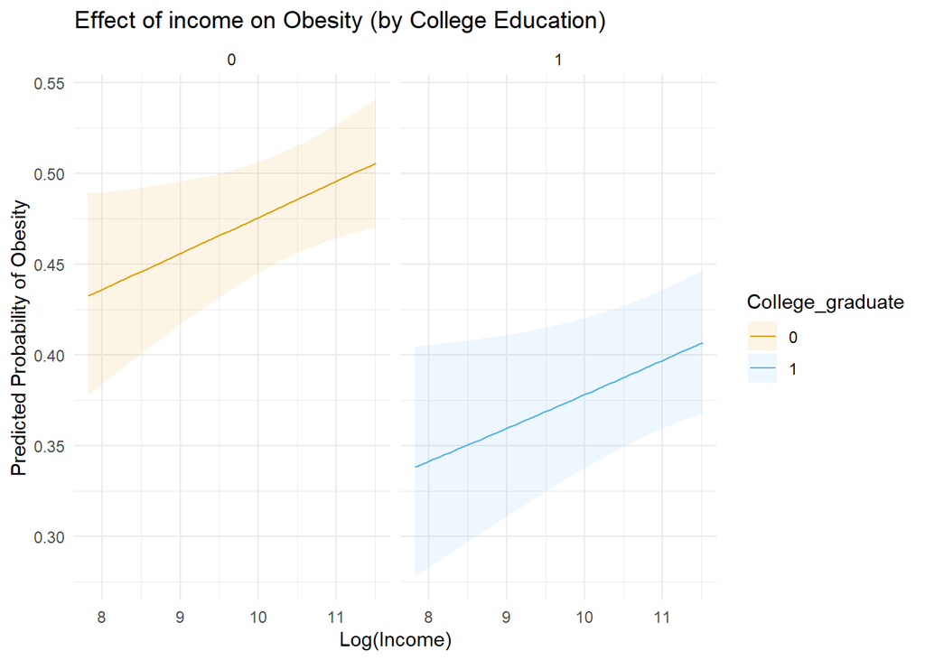

```r
plot_predictions(logit_full_model, condition = list("Income", "College_graduate"))+
  labs(title = "Effect of income on Obesity (by College Education)",
       x = "Log(Income)",
       y = "Predicted Probability of Obesity") +
  facet_wrap(~College_graduate) +  # Creates separate plots for each group
  theme_minimal()
```

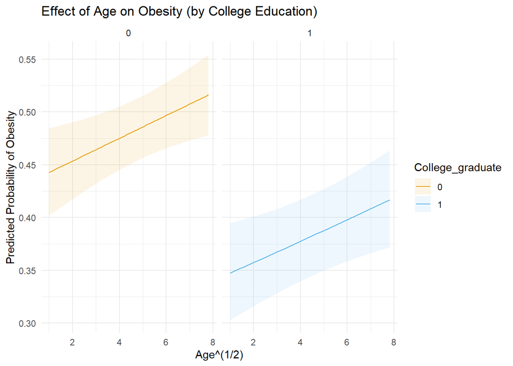

```r
#Effect of Age on Obesity (by College Education)

plot_predictions(logit_full_model, condition = list("Age_Years", "College_graduate"))+
  labs(title = "Effect of Age on Obesity (by College Education)",
       x = "Age^(1/2)",
       y = "Predicted Probability of Obesity") +
  facet_wrap(~College_graduate) +  # Creates separate plots for each group
  theme_minimal()
```